# beer_analysis

Jostein Barry-Straume

7/1/2017

# Craft Beers and Breweries in the USA

## By [Jostein Barry-Straume](https://github.com/josteinstraume)

[Data Science @ Southern Methodist University](https://datascience.smu.edu/)

# Table of Contents

1. Introduction
2. Data sets descriptions
   - Variable names
3. Analysis
4. Conclusion

# Introduction

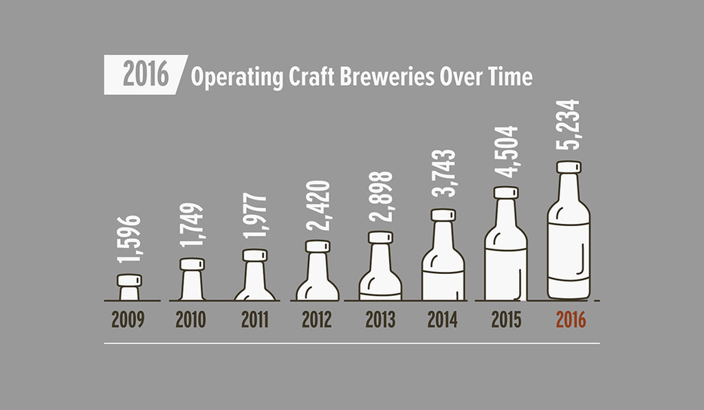

Source: CraftBeer.com

> The craft beer industry continues its growth nationally, albeit with decaying rates. This is indicative that the market surrounding craft beer has reached maturity. As the craft beer industry comes of age, in order to maintain a competitive advantage in a saturated market it is important for breweries to make informed decisions regarding their selection of offerings to customers.

[figure not shown]

Source: BrewersAssociation.org

> While the amount of beer spilled from the productions lines of Anheuser Busch is greater than total volume of beer Samuel Adams produces, the craft beer industry still has a significant foothold in overall beer sales. Brewers Association reports that not only has production of craft beer increased 6.2% in 2016, but exports of craft beer have increased by 4.4% as well.

> In this report we will delve into the distribution of breweries across the USA, and the composition of their respective beers offered. In particular, the relationship between International Bitterness Units and Alcohol by Volume will explored. Additionally, insight into customer preferences will be brought to light by discerning from which states the most potent and most bitter beers are brewed.

# Data set descriptions

> Beers data set contains a list of 2410 US craft beers Breweries data set contains 558 US breweries. The variable names and their descriptions are as follows.
- Beers.csv:
  - Name: Name of the beer.
  - Beer ID: Unique identifier of the beer.
  - ABV: Alcohol by volume of the beer.
  - IBU: International Bitterness Units of the beer.
  - Brewery ID: Brewery id associated with the beer.
  - Style: Style of the beer.
  - Ounces: Ounces of beer.
- Breweries.csv:
  - Brew ID: Unique identifier of the brewery.
  - Name: Name of the brewery.
  - City: City where the brewery is located.
  - State: State where the brewery is located.

# Analysis

## Import data sets and look at their structures

```r
beer <- read.csv("/Users/Jostein/Grad School/SMU/Doing_Data_Science/unit_8/msds6306_casestudy01/data/Beers.csv", header=TRUE, stringsAsFactors = TRUE)

breweries <- read.csv("/Users/Jostein/Grad School/SMU/Doing_Data_Science/unit_8/msds6306_casestudy01/data/Breweries.csv", header=TRUE, stringsAsFactors = TRUE)

str(beer)
```

```
## 'data.frame':    2410 obs. of  7 variables:
##  $ Name      : Factor w/ 2305 levels "#001 Golden Amber Lager",..: 1638 577 1704 1842 1819 268 1160 758 1093 486 ...
##  $ Beer_ID   : int  1436 2265 2264 2263 2262 2261 2260 2259 2258 2131 ...
##  $ ABV       : num  0.05 0.066 0.071 0.09 0.075 0.077 0.045 0.065 0.055 0.086 ...
##  $ IBU       : int  NA NA NA NA NA NA NA NA NA NA ...
##  $ Brewery_id: int  409 178 178 178 178 178 178 178 178 178 ...
##  $ Style     : Factor w/ 100 levels "","Abbey Single Ale",..: 19 18 16 12 16 80 18 22 18 12 ...
##  $ Ounces    : num  12 12 12 12 12 12 12 12 12 12 ...
```

```r
str(breweries)
```

```
## 'data.frame':    558 obs. of  4 variables:
##  $ Brew_ID: int  1 2 3 4 5 6 7 8 9 10 ...
##  $ Name   : Factor w/ 551 levels "10 Barrel Brewing Company",..: 355 12 266 319 201 136 227 477 59 491 ...
##  $ City   : Factor w/ 384 levels "Abingdon","Abita Springs",..: 228 200 122 299 300 62 91 48 152 136 ...
##  $ State  : Factor w/ 51 levels " AK"," AL"," AR",..: 24 18 20 5 5 41 6 23 23 23 ...
```

## How many breweries are present in each state?

> Count the number of breweries by state, and then use that as a basis for a barplot in order to visually discern the distributions of breweries among states.

```r
library(plyr)
breweries_by_state <- count(breweries, "State")
breweries_by_state
```

```
##    State freq
## 1     AK    7
## 2     AL    3
## 3     AR    2
## 4     AZ   11
## 5     CA   39
## 6     CO   47
## 7     CT    8
## 8     DC    1
## 9     DE    2
## 10    FL   15
## 11    GA    7
## 12    HI    4
## 13    IA    5
## 14    ID    5
```

[output cut: 37 more lines]

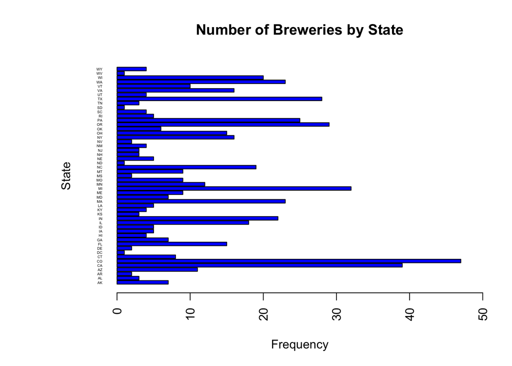

```r
# Setting values so each state displays properly in the bar plot.
par(las=2)
par(mar=c(5,8,4,2))

# Barplot of number of breweries in each state.
barplot(breweries_by_state$freq, xlab = "Frequency", ylab = "State", main = "Number of Breweries by State", horiz = TRUE, names.arg = breweries_by_state$State, cex.names = 0.3, col = "blue", xlim = c(0, 50))
```

> It would appear that the amount of breweries in a given state ranges from as few as one, to as many as 47.

## Merge data sets

> Merge the beer data set with the breweries data set by Brewery ID. Print first 6 observations and the last six observations to validate that the merging of data sets was done correctly.

```r
# Merging the beer data set and the breweries data set by Brewery ID.
beer_and_breweries <- merge(beer, breweries, by.x = "Brewery_id", by.y = "Brew_ID", all = TRUE, sort = TRUE)
str(beer_and_breweries)
```

```
## 'data.frame':    2410 obs. of  10 variables:
##  $ Brewery_id: int  1 1 1 1 1 1 2 2 2 2 ...
##  $ Name.x    : Factor w/ 2305 levels "#001 Golden Amber Lager",..: 802 1258 2185 1640 1926 1525 458 1218 43 71 ...
##  $ Beer_ID   : int  2692 2691 2690 2689 2688 2687 2686 2685 2684 2683 ...
##  $ ABV       : num  0.045 0.049 0.048 0.06 0.06 0.056 0.08 0.125 0.077 0.042 ...
##  $ IBU       : int  50 26 19 38 25 47 68 80 25 42 ...
##  $ Style     : Factor w/ 100 levels "","Abbey Single Ale",..: 16 77 48 83 22 57 12 46 77 18 ...
##  $ Ounces    : num  16 16 16 16 16 16 16 16 16 16 ...
##  $ Name.y    : Factor w/ 551 levels "10 Barrel Brewing Company",..: 355 355 355 355 355 355 12 12 12 12 ...
##  $ City      : Factor w/ 384 levels "Abingdon","Abita Springs",..: 228 228 228 228 228 228 200 200 200 200 ...
##  $ State     : Factor w/ 51 levels " AK"," AL"," AR",..: 24 24 24 24 24 24 18 18 18 18 ...
```

```r
# Printing the first six observations.
head(beer_and_breweries, n = 6)
```

```
##   Brewery_id        Name.x Beer_ID   ABV IBU
## 1          1  Get Together    2692 0.045  50
## 2          1 Maggie's Leap    2691 0.049  26
## 3          1    Wall's End    2690 0.048  19
## 4          1       Pumpion    2689 0.060  38
## 5          1    Stronghold    2688 0.060  25
## 6          1   Parapet ESB    2687 0.056  47
##                                 Style Ounces             Name.y
## 1                        American IPA     16 NorthGate Brewing
## 2                  Milk / Sweet Stout     16 NorthGate Brewing
## 3                   English Brown Ale     16 NorthGate Brewing
## 4                         Pumpkin Ale     16 NorthGate Brewing
## 5                     American Porter     16 NorthGate Brewing
## 6 Extra Special / Strong Bitter (ESB)     16 NorthGate Brewing
##          City State
## 1 Minneapolis    MN
## 2 Minneapolis    MN
## 3 Minneapolis    MN
## 4 Minneapolis    MN
## 5 Minneapolis    MN
## 6 Minneapolis    MN
```

```r
# Printing the last six observations.
tail(beer_and_breweries, n = 6)
```

```
##      Brewery_id                    Name.x Beer_ID   ABV IBU
## 2405        556             Pilsner Ukiah      98 0.055  NA
## 2406        557  Heinnieweisse Weissebier      52 0.049  NA
## 2407        557           Snapperhead IPA      51 0.068  NA
## 2408        557         Moo Thunder Stout      50 0.049  NA
## 2409        557         Porkslap Pale Ale      49 0.043  NA
## 2410        558 Urban Wilderness Pale Ale      30 0.049  NA
##                        Style Ounces                        Name.y
## 2405         German Pilsener     12         Ukiah Brewing Company
## 2406              Hefeweizen     12       Butternuts Beer and Ale
## 2407            American IPA     12       Butternuts Beer and Ale
## 2408      Milk / Sweet Stout     12       Butternuts Beer and Ale
## 2409 American Pale Ale (APA)     12       Butternuts Beer and Ale
## 2410        English Pale Ale     12 Sleeping Lady Brewing Company
##               City State
## 2405         Ukiah    CA
## 2406 Garrattsville    NY
## 2407 Garrattsville    NY
## 2408 Garrattsville    NY
## 2409 Garrattsville    NY
## 2410     Anchorage    AK
```

> The beer data set and the breweries data set have now been merged to create the beer_and_breweries data set.

## Reporting NA values

> Report the number of NA’s in each column.

```r
# Using the Sapply function we can easily count the number of NA values per column in the data set.
na_counts <- sapply(beer_and_breweries, function(y) sum(is.na(y)))
na_counts
```

```
## Brewery_id     Name.x    Beer_ID        ABV        IBU      Style
##          0          0          0         62       1005          0
##     Ounces     Name.y       City      State
##          0          0          0          0
```

> The Alcohol by Volume column of the data set contains 62 NA values, whereas the International Bitterness Units column contains a staggering 1005 NA values. I suspect the explanation behind these missing values is because calculating a beer’s “metadata” requires extra steps in the brewing process, as well as additional gear to figure out the bitterness of a craft beer.

## Exploring ABV and IBU for each state

> Compute the median alcohol content and international bitterness unit for each state. Plot a bar chart to compare.

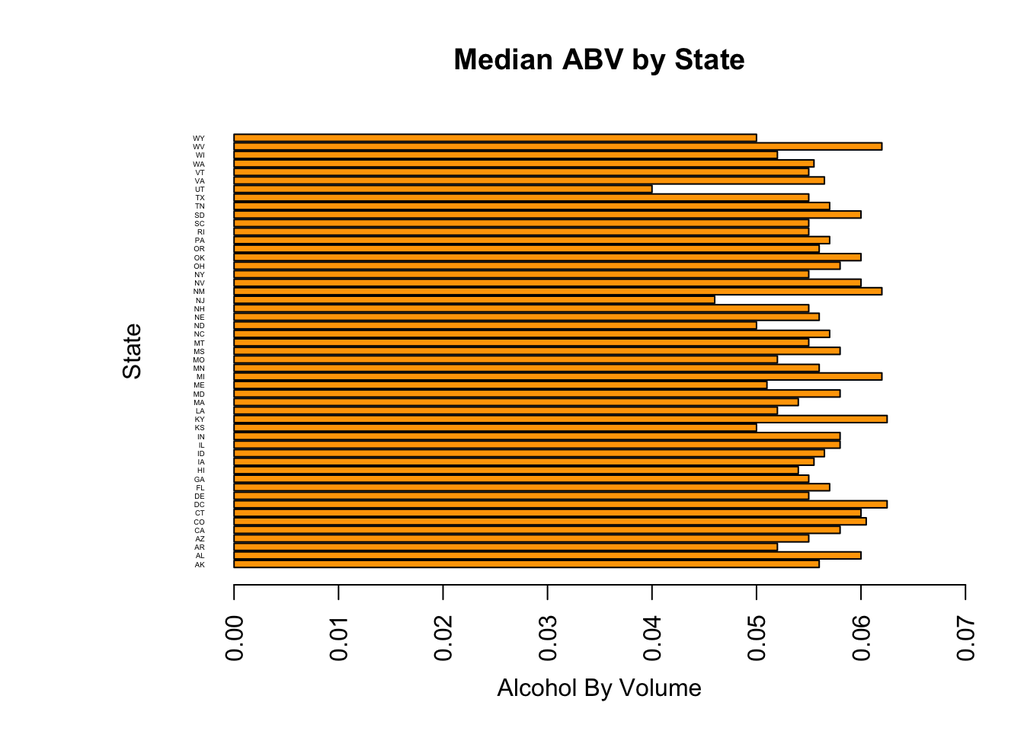

```r
# Attaching merged data set to more easily refer to while performing analysis.
attach(beer_and_breweries)

# Ouputs medians of alcohol by volume for each state.
median_abv_state <- aggregate(ABV ~ State, data = beer_and_breweries, median)

# Setting values so each state displays properly in the bar plot.
par(las=2)
par(mar=c(5,8,4,2))

# Barplot listing the median alcohol content of beer for each state.
barplot(median_abv_state$ABV, xlab = "Alcohol By Volume", ylab = "State", main = "Median ABV by State", horiz = TRUE, names.arg = median_abv_state$State, cex.names = 0.3, col = "orange", xlim = c(0, 0.07))
```

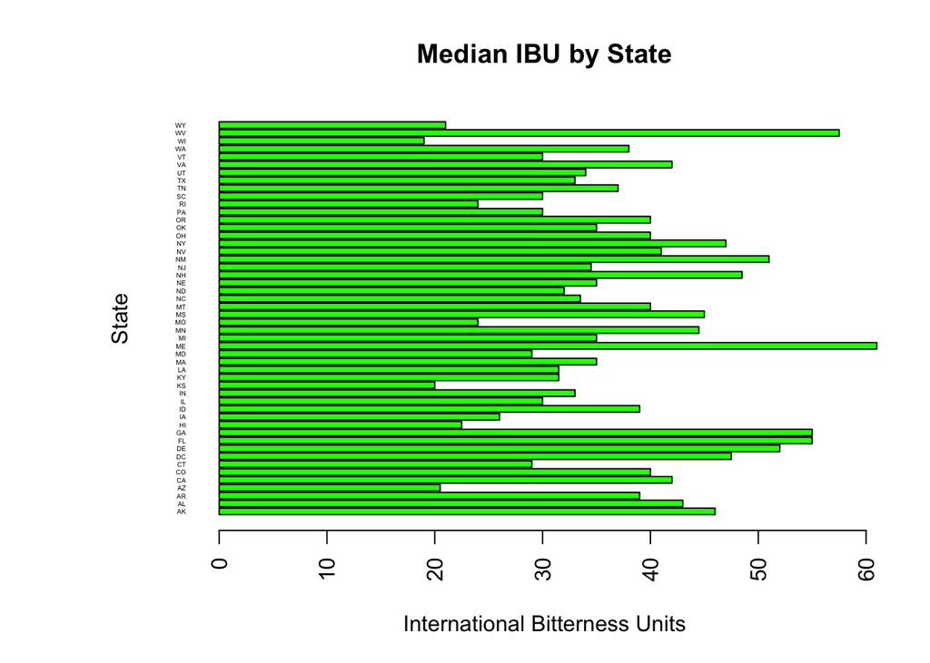

```r
# Ouputs medians of international bitterness units for each state.
median_ibu_state <- aggregate(IBU ~ State, data = beer_and_breweries, median)

# Barplot listing the median international bitterness units of beer for each state.
barplot(median_ibu_state$IBU, xlab = "International Bitterness Units", ylab = "State", main = "Median IBU by State", horiz = TRUE, names.arg = median_ibu_state$State, cex.names = 0.3, col = "green")
```

> It would appear that Utah has the lowest median of alcohol by volume, whereas Wisconsin has the lowest median of international bitterness units.

## Beers that pack a punch

> Which state has the maximum alcoholic beer? Which state has the most bitter beer?

```r
# Calculate max ABV of each state
max_abv <- aggregate(ABV ~ State, data = beer_and_breweries, function(x) max(x))

# Pull the index of the overall maximum ABV and
# return the corresponding row displaying the respective state
max_abv[which.max(max_abv$ABV),]
```

```
##   State   ABV
## 6    CO 0.128
```

```r
# Calculate max IBU of each state
max_ibu <- aggregate(IBU ~ State, data = beer_and_breweries, function(x) max(x))

# Pull the index of the overall maximum IBU and
# return the corresponding row displaying the respective state
max_ibu[which.max(max_ibu$IBU),]
```

```
##    State IBU
## 38    OR 138
```

> Colorado brews the strongest beer, whereas Oregon produces the most bitter beer.

## Overview of Alcohol by Volume

> Summary statistics for ABV (Alcohol by Volume) variable

```r
# Summary statistics for ABV by state
aggregate(ABV ~ State, data = beer_and_breweries, summary)
```

```
##    State   ABV.Min. ABV.1st Qu. ABV.Median   ABV.Mean ABV.3rd Qu.
## 1     AK 0.04800000  0.05000000 0.05600000 0.05564000  0.05900000
## 2     AL 0.05000000  0.05650000 0.06000000 0.06200000  0.06000000
## 3     AR 0.04000000  0.05000000 0.05200000 0.05200000  0.05700000
## 4     AZ 0.04200000  0.05200000 0.05500000 0.06022727  0.06750000
## 5     CA 0.00100000  0.05000000 0.05800000 0.06108242  0.07000000
## 6     CO 0.04100000  0.05200000 0.06050000 0.06337200  0.07075000
## 7     CT 0.03400000  0.05000000 0.06000000 0.06107407  0.07000000
## 8     DC 0.05000000  0.05450000 0.06250000 0.06562500  0.07250000
## 9     DE 0.05500000  0.05500000 0.05500000 0.05500000  0.05500000
## 10    FL 0.03800000  0.05275000 0.05700000 0.05994643  0.07000000
## 11    GA 0.04500000  0.04975000 0.05500000 0.05637500  0.06250000
## 12    HI 0.04200000  0.04950000 0.05400000 0.05729630  0.06400000
## 13    IA 0.04800000  0.05000000 0.05550000 0.05950000  0.06725000
## 14    ID 0.04200000  0.05000000 0.05650000 0.06070000  0.06375000
```

[output cut: 89 more lines]

```r
# Overall summary statistics for ABV
summary(ABV)
```

```
##    Min. 1st Qu.  Median    Mean 3rd Qu.    Max.    NA's
## 0.00100 0.05000 0.05600 0.05977 0.06700 0.12800      62
```

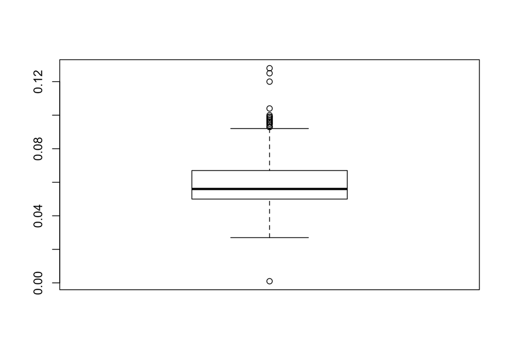

```r
# Box and whisker plot of ABV
boxplot(ABV)
```

> The distribution of Alcohol by Volume is right skewed. This fact is confirmed by both the summary statistics and the boxplot of the data. The summary statistics tell us that the mean is larger than the median. Likewise, the boxplot contains numerous potential outliers for beers with a larger ABV value.

## Exploring the relationship between IBU and ABV

> Is there a relationship between the bitterness of the beer and its alcoholic content? Draw a scatter plot.

```r
# Output correlation coefficient.
cor(IBU, ABV, use = "complete.obs")
```

```
## [1] 0.6706215
```

```r
# Test for whether correlation is 0 (H0) or not 0 (Ha) and CI.
# Also gives sample correlation.
cor.test(IBU, ABV)
```

```
##
##  Pearson's product-moment correlation
##
## data:  IBU and ABV
## t = 33.863, df = 1403, p-value < 2.2e-16
## alternative hypothesis: true correlation is not equal to 0
## 95 percent confidence interval:
##  0.6407982 0.6984238
## sample estimates:
##       cor
## 0.6706215
```

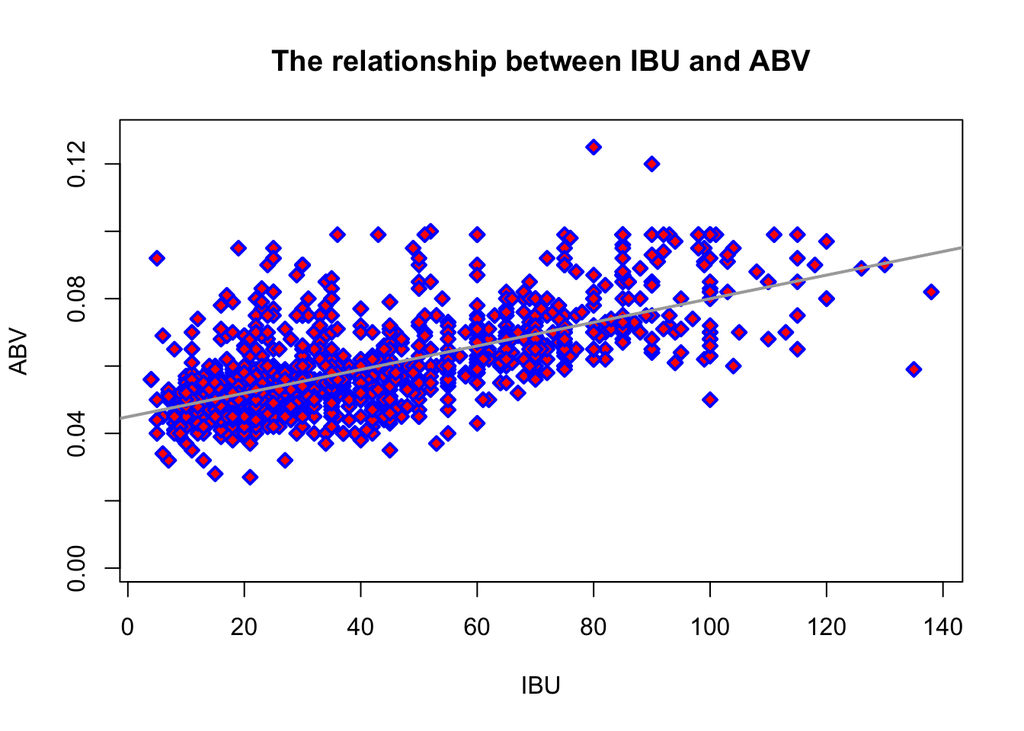

```r
# Scatter plot of the relationship between IBU and ABV
plot(IBU, ABV, pch = 23, col = "blue", bg = "red", lwd = 2, main = "The relationship between IBU and ABV")

# Adding a trend line (least squares regression line) to the plot.
abline(lm(ABV~IBU), col = "darkgray", lwd = 2)
```

> Null Hypothesis: The correlation between IBU and ABV is zero.

> Alternative Hypothesis: The correlation between IBU and ABV is not zero.

> A correlation coefficient of 0.6706215 indicates a moderate-to-strong positive relationship between International Bitterness Units and Alcohol by Volume.

> We are 95% confident that the correlation coefficient between IBU and ABV is between 0.6407982 and 0.6984238. With a resulting p-value that is less than 2.2e-16, we reject the null hypothesis. In other words, the data is highly unplausible under the null hypothesis, so we have reason to believe that there is not a zero correlation relationship between International Bitterness Units and Alcohol by Volume.

# Conclusion

> Summary of findings from this report.
- The amount of breweries in a given state ranges from as few as one, to as many as 47.
- Merging the beer data set with the breweries data set results in:
  - 62 NA values for Alcohol by Volume.
  - 1005 NA values for International Bitterness Units.
- Utah has the lowest median of alcohol by volume, whereas Wisconsin has the lowest median of international bitterness units.
- Colorado brews the strongest beer, whereas Oregon produces the most bitter beer.
- Summary statistics of Alcohol by Volume:
  - Min = 0.00100.
  - 1st Quartile = 0.05000.
  - Median = 0.05600.
  - Mean = 0.05977.
  - 3rd Quartile = 0.06700.
  - Max = 0.12800.
  - Distribution = Right-skewed.
- Relationship between International Bitterness Units and Alcohol by Volume:
  - Moderate-to-strong positive linear relationship.
  - Correlation Coefficient = 0.6706215.
  - 95% Confidence Interval for Correlation Coefficient = [0.6407982, 0.6984238].